# EDA_GoodQuality+Model_final

### h.Money Value Calculation

```python
#customer_windowed_ga
#windows
#orders
#sales
#windows.columns
customer_windowed_ga
```

|  | sales_office | customer_id | sales_office_description | distribution_mode_description | shipping_conditions_description | cold_drink_channel_description | customer_sub_trade_channel_description | added_in_window | purchased_in_window | is_abandoned_count | ... | event_page_name_MyCoke Support History - Customer Services | event_page_name_Order History | event_page_name_Product Details | event_page_name_Product List | event_page_name_Profile Screen | event_page_name_Public About MyCoke | event_page_name_Public Contact Us | event_page_name_Public Frequently Asked Questions | event_page_name_Support History | event_page_name_No_Page |
| --- | --- | --- | --- | --- | --- | --- | --- | --- | --- | --- | --- | --- | --- | --- | --- | --- | --- | --- | --- | --- | --- |
| 0 | G111 | 500964906 | Draper, UT | Sideload | 48 Hours | Restaurant | Dining | 1.0 | 10.0 | 0.0 | ... | 0 | 0 | 0 | 6 | 1 | 0 | 0 | 0 | 0 | 372 |
| 1 | G111 | 501543906 | Draper, UT | Sideload | 48 Hours | Restaurant | Mexican Fast Food | 9.0 | 10.0 | 0.0 | ... | 0 | 0 | 0 | 0 | 0 | 0 | 0 | 0 | 0 | 287 |
| 2 | G293 | 501394111 | Tacoma, WA | OFS | 24 Hours | Attraction | Recreation Center | 0.0 | 0.0 | 0.0 | ... | 0 | 0 | 0 | 0 | 0 | 0 | 0 | 0 | 0 | 12 |
| 3 | G238 | 501528559 | Colorado Springs, CO | OFS | 48 Hours | Attraction | Recreation Center | 3.0 | 2.0 | 1.0 | ... | 0 | 0 | 0 | 0 | 0 | 0 | 0 | 0 | 0 | 41 |
| 4 | G132 | 500504789 | Alamosa, CO | OFS | 48 Hours | Restaurant | Fast Food | 37.0 | 36.0 | 1.0 | ... | 0 | 0 | 0 | 0 | 0 | 0 | 0 | 0 | 0 | 172 |
| ... | ... | ... | ... | ... | ... | ... | ... | ... | ... | ... | ... | ... | ... | ... | ... | ... | ... | ... | ... | ... | ... |
| 6329 | G235 | 500529678 | Johnstown, CO | Sideload | 48 Hours | Hotel | Motel | 10.0 | 7.0 | 3.0 | ... | 0 | 0 | 0 | 0 | 0 | 0 | 2 | 0 | 0 | 28 |
| 6330 | G143 | 600082401 | Boise, ID | Sideload | 48 Hours | Institution | Government Office | 2.0 | 2.0 | 0.0 | ... | 0 | 0 | 0 | 0 | 0 | 0 | 0 | 0 | 0 | 110 |
| 6331 | G121 | 501708743 | Ogden, UT | Sideload | 48 Hours | Store | Auto Service | 9.0 | 9.0 | 0.0 | ... | 0 | 0 | 0 | 0 | 0 | 3 | 0 | 0 | 0 | 155 |
| 6332 | G121 | 501494684 | Ogden, UT | Sideload | 48 Hours | Restaurant | Pizza Fast Food | 12.0 | 9.0 | 5.0 | ... | 2 | 0 | 0 | 0 | 0 | 0 | 0 | 0 | 0 | 170 |
| 6333 | G121 | 501775200 | Ogden, UT | Sideload | 48 Hours | Workplace | Industrial Supply | 1.0 | 1.0 | 0.0 | ... | 0 | 0 | 0 | 0 | 0 | 0 | 0 | 0 | 0 | 45 |

6334 rows × 77 columns

```python
# Load your sales data
sales = pd.read_csv("sales.csv")
# Clean missing data (just in case)
sales["NSI_DEAD_NET"] = sales["NSI_DEAD_NET"].fillna(0)
sales["PHYSICAL_VOLUME"] = sales["PHYSICAL_VOLUME"].fillna(0)

# Compute REV_PER_UNIT
total_revenue = sales["NSI_DEAD_NET"].sum()
total_units = sales["PHYSICAL_VOLUME"].sum()

REV_PER_UNIT = total_revenue / total_units

print("Real REV_PER_UNIT:", REV_PER_UNIT)
```

```
Real REV_PER_UNIT: 26.43209609891005
```

```python
# Work on a COPY so the original model data is untouched
windows_money = windows.copy(deep=True)

# Set estimated revenue per unit (from Sales analysis)
REV_PER_UNIT = 26.423153241796854  # example value, adjust if needed

# Create an estimated number of units in the cart per window
# Use the running average units per order; fall back to avg_units_per_order if needed.
windows_money["est_cart_units"] = (
    windows_money["avg_units_per_order_running"]
    .fillna(windows_money["avg_units_per_order"])
    .fillna(0)
)

# Create the per-window dollar column that was missing: est_cart_value
# Formula: est_cart_value = est_cart_units × revenue_per_unit
windows_money["est_cart_value"] = windows_money["est_cart_units"] * REV_PER_UNIT

# Focus on true abandoned-cart windows where a cart actually existed
abandoned = windows_money.query("is_abandoned == True and added_in_window == True")

# Money KPIs at window level

# Total abandoned windows
total_abandoned_windows = len(abandoned)

# Total lost revenue from abandonment
# Formula: total_lost_revenue = Σ est_cart_value over all abandoned windows
total_lost_revenue = abandoned["est_cart_value"].sum()

# Average value at stake per abandoned order window
# Formula: value_at_stake_per_window = total_lost_revenue / total_abandoned_windows
value_at_stake_per_window = (
    total_lost_revenue / total_abandoned_windows if total_abandoned_windows > 0 else 0
)

# Unstablecustomers = sometimes order, sometimes abandon
cust_abn_stats = windows_money.groupby("customer_id")["is_abandoned"].agg(["any", "all"])
unstable_customer_ids = cust_abn_stats.query("any == True and all == False").index

# Only look at abandoned windows belonging to unstable customers
unstable_abandoned = abandoned[abandoned["customer_id"].isin(unstable_customer_ids)]

num_unstable_customers = unstable_abandoned["customer_id"].nunique()

# Average order value at risk from unstable customers (on their abandoned windows)
# Formula: avg_value_at_risk_unstable = Σ est_cart_value (unstable abandoned) / #unstable customers
avg_value_at_risk_unstable = (
    unstable_abandoned["est_cart_value"].sum() / num_unstable_customers
    if num_unstable_customers > 0
    else 0
)

print(" Money Metrics from Window-Level Data")
print(f"Estimated revenue per unit: ${REV_PER_UNIT:,.2f}")
print(f"Total abandoned windows: {total_abandoned_windows:,}")
print(f"Estimated total lost revenue from abandonment: ${total_lost_revenue:,.0f}")
print(f"Value at stake per abandoned order window (avg): ${value_at_stake_per_window:,.2f}")
print(f"Number of unstable customers: {num_unstable_customers:,}")
print(f"Average order value at risk from unstable customers: ${avg_value_at_risk_unstable:,.2f}")

# Apply model performance to estimate financial recovery

DETECTION_RECALL = 0.87   # change to your actual recall for class "abandoned"

# Try different recovery rates after messaging (how many of those detected carts you save)
recovery_rates = [0.10, 0.20, 0.25, 0.50, 0.75, 1.00]  # 10%, 20%, 25%, 50%, 75%, 100%

print("\n=== Business Opportunity Scenarios (Model + Recovery) ===")
for r in recovery_rates:
    # Formula:
    # recovered_revenue = total_lost_revenue × detection_recall × recovery_rate
    recovered_revenue = total_lost_revenue * DETECTION_RECALL * r
    print(f"{int(r*100):>3d}% recovery: ${recovered_revenue:,.0f} potential savings")
```

```
 Money Metrics from Window-Level Data
Estimated revenue per unit: $26.42
Total abandoned windows: 3,092
Estimated total lost revenue from abandonment: $246,944
Value at stake per abandoned order window (avg): $79.87
Number of unstable customers: 1,752
Average order value at risk from unstable customers: $134.38

=== Business Opportunity Scenarios (Model + Recovery) ===
 10% recovery: $21,484 potential savings
 20% recovery: $42,968 potential savings
 25% recovery: $53,710 potential savings
 50% recovery: $107,421 potential savings
 75% recovery: $161,131 potential savings
100% recovery: $214,841 potential savings
```

```python
# Only look at windows that were truly abandoned AND had items added
abandoned_windows = windows_money.query("is_abandoned == True and added_in_window == True")

# Total lost revenue from abandoned windows
total_lost_revenue = abandoned_windows["est_cart_value"].sum()

# Number of abandoned windows
n_abandoned_windows = len(abandoned_windows)

# Value per abandoned window (REAL)
value_at_stake_per_window = (
    total_lost_revenue / n_abandoned_windows
    if n_abandoned_windows > 0 else 0
)

print("Total lost revenue:", total_lost_revenue)
print("Number of abandoned windows:", n_abandoned_windows)
print("Value per window:", value_at_stake_per_window)
```

```
Total lost revenue: 246943.80918807135
Number of abandoned windows: 3092
Value per window: 79.86539753818607
```

```python
cust = customer_windowed_ga.copy(deep=True)

# Bring in the correct value per abandoned window
VALUE_PER_WINDOW = value_at_stake_per_window

# Calculate value at risk per customer
cust["value_at_risk_customer"] = (
    cust["is_abandoned_count"].fillna(0) * VALUE_PER_WINDOW
)

#Customer-level total lost revenue
total_customer_loss = cust["value_at_risk_customer"].sum()

# Average lost revenue per customer
avg_lost_per_customer = cust["value_at_risk_customer"].mean()

# Unstable customers = customers with both abandonments AND purchases
unstable_mask = (
    (cust["is_abandoned_count"] > 0) &
    (cust["purchased_in_window"] > 0)
)

unstable_customers = cust[unstable_mask]
num_unstable_customers = unstable_customers["customer_id"].nunique()

avg_risk_unstable = (
    unstable_customers["value_at_risk_customer"].mean()
    if num_unstable_customers > 0 else 0
)

# Business opportunity scenarios (10/25/50/75% reduction)
reduction_rates = [0.10, 0.25, 0.50, 0.75]

# Model-driven recovery using REAL Recall = 0.48
MODEL_RECALL = 0.48
messaging_recovery_rates = [0.10, 0.20, 0.25, 0.50, 1.00]

# PRINT RESULTS
print("=== CUSTOMER-LEVEL MONEY METRICS ===")
print(f"Total customers: {len(cust):,}")
print(f"Total customer-level abandonment cost: ${total_customer_loss:,.0f}")
print(f"Average value at risk per customer: ${avg_lost_per_customer:,.2f}")

print("\n=== UNSTABLE CUSTOMERS ===")
print(f"Number of unstable customers: {num_unstable_customers:,}")
print(f"Avg value at risk (unstable customers): ${avg_risk_unstable:,.2f}")

print("\n=== BUSINESS OPPORTUNITY (REDUCE ABANDONMENT) ===")
for r in reduction_rates:
    print(f"{int(r*100)}% reduction: ${total_customer_loss*r:,.0f}")

print("\n=== MODEL-DRIVEN RECOVERY (Recall = 0.48) ===")
for rr in messaging_recovery_rates:
    recovered = total_customer_loss * MODEL_RECALL * rr
    print(f"Recover {int(rr*100)}% of detected abandonments: ${recovered:,.0f}")
```

```
=== CUSTOMER-LEVEL MONEY METRICS ===
Total customers: 6,334
Total customer-level abandonment cost: $246,944
Average value at risk per customer: $38.99

=== UNSTABLE CUSTOMERS ===
Number of unstable customers: 1,651
Avg value at risk (unstable customers): $134.53

=== BUSINESS OPPORTUNITY (REDUCE ABANDONMENT) ===
10% reduction: $24,694
25% reduction: $61,736
50% reduction: $123,472
75% reduction: $185,208

=== MODEL-DRIVEN RECOVERY (Recall = 0.48) ===
Recover 10% of detected abandonments: $11,853
Recover 20% of detected abandonments: $23,707
Recover 25% of detected abandonments: $29,633
Recover 50% of detected abandonments: $59,267
Recover 100% of detected abandonments: $118,533
```

# Predictive Machine Learning Model

```python
# data Check
# windows.info()
```

```python
windows['is_abandoned'].value_counts(normalize=True).mul(100).round(2)
```

```
is_abandoned
0    94.11
1     5.89
Name: proportion, dtype: float64
```

## Customer Level Modeling

```
Model Performance:
Accuracy: 0.789

Classification Report:
               precision    recall  f1-score   support

       False       0.81      0.92      0.86      1148
        True       0.72      0.47      0.57       483

    accuracy                           0.79      1631
   macro avg       0.76      0.70      0.71      1631
weighted avg       0.78      0.79      0.77      1631


 Feature Importances:
                                               feature    importance
90                event_page_name_MyCoke Orders - Cart  1.053433e-01
89                       event_page_name_MyCoke Orders  7.785096e-02
106                            event_page_name_No_Page  6.350770e-02
92           event_page_name_MyCoke Orders - Product:   5.746641e-02
70                                 avg_units_per_order  5.332138e-02
..                                                 ...           ...
47             distribution_mode_description_Night OFS  6.887596e-06
45             distribution_mode_description_EZ Pallet  5.127829e-06
57   shipping_conditions_description_Dropsite 24 Hours  1.312213e-07
17                                   sales_office_G165  2.120647e-19
98                       event_page_name_Order History  0.000000e+00

[107 rows x 2 columns]
```

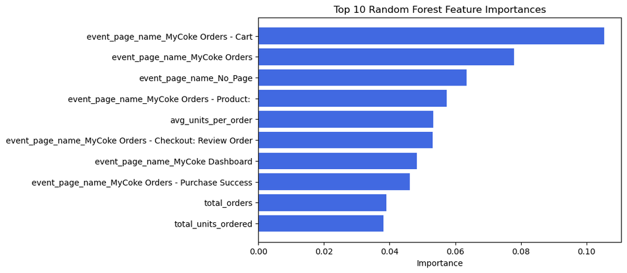

```python
data = customer_windowed_ga.dropna()


y = data['is_abandoned_count'] >0
X = data.drop(
    columns = ['is_abandoned_count',
               'customer_id',
               'sales_office_description',
               'missed_reorder',
               'added_in_window',
               'added_to_cart',
               'mean_nsi_dead_net',
               'customer_sub_trade_channel_description'
                        ]
)

# Split data into train/test

X_train, X_test, y_train, y_test = train_test_split(X, y, test_size=0.3, random_state=42)

# Preprocess categorical variables

categorical_features = ['sales_office',
                        'distribution_mode_description',
                        'shipping_conditions_description',
                        'cold_drink_channel_description'
                        #'customer_sub_trade_channel_description',
                       ]
numeric_features = ['total_orders',
                    #'added_in_window',
                   'total_units_ordered',
                   'avg_units_per_order',
                   #'added_to_cart',
                   'mean_profit_dead_net',
                   'mean_physical_volume',
                   #'mean_nsi_dead_net',
                    'rolling_mean_gross_profit',
                    'rolling_mean_physical_volume',
                    'purchased_in_window',
                    #'page_visits'
                   ]

# Fix ga_dummies to be a df and combine with numeric_features
ga_dummies = ga_customer.iloc[:, 1:]
numeric_features += list(ga_dummies.columns)

# One-hot encode categorical variables
preprocessor = ColumnTransformer(
    transformers=[
        ('cat', OneHotEncoder(handle_unknown='ignore'), categorical_features),
        ('num', 'passthrough', numeric_features)
    ]
)

# Build the Random Forest pipeline

rf = RandomForestClassifier(
    class_weight = 'balanced',
    n_estimators=1000,
    random_state=1424,
    bootstrap=True,
    n_jobs=-1
)

model = Pipeline(steps=[
    ('preprocess', preprocessor),
    ('rf', rf)
])

# Train the model

model.fit(X_train, y_train)

# Evaluate the model

y_pred = model.predict(X_test)
print("Model Performance:")
print("Accuracy:", round(accuracy_score(y_test, y_pred), 3))
print("\nClassification Report:\n", classification_report(y_test, y_pred))

# Get expanded feature importances

# Extract feature names from the ColumnTransformer
encoder = model.named_steps['preprocess'].named_transformers_['cat']
encoded_cat_features = encoder.get_feature_names_out(categorical_features)
all_feature_names = list(encoded_cat_features) + numeric_features

# Get feature importances from the random forest
importances = model.named_steps['rf'].feature_importances_

# Combine into a DataFrame
importance_df = pd.DataFrame({
    'feature': all_feature_names,
    'importance': importances
}).sort_values('importance', ascending=False)

print("\n Feature Importances:")
print(importance_df)

# Plot feature importances

top_n = 10
top_features = importance_df.head(top_n)

plt.figure(figsize=(8, 5))
plt.barh(top_features['feature'], top_features['importance'], color='royalblue')
plt.gca().invert_yaxis()  # So the most important feature is at the top
plt.xlabel("Importance")
plt.title(f"Top {top_n} Random Forest Feature Importances")
plt.show()
```

```
Model Performance:
Accuracy: 0.789
AUC: 0.868

Classification Report:
               precision    recall  f1-score   support

       False       0.81      0.92      0.86      1148
        True       0.72      0.47      0.57       483

    accuracy                           0.79      1631
   macro avg       0.76      0.70      0.71      1631
weighted avg       0.78      0.79      0.77      1631
```

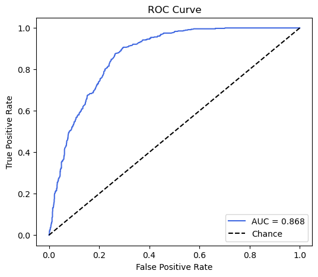

```python
y_pred = model.predict(X_test)
y_proba = model.predict_proba(X_test)[:, 1]

print("Model Performance:")
print("Accuracy:", round(accuracy_score(y_test, y_pred), 3))
print("AUC:", round(roc_auc_score(y_test, y_proba), 3))
print("\nClassification Report:\n", classification_report(y_test, y_pred))

# ROC Curve
fpr, tpr, _ = roc_curve(y_test, y_proba)
plt.figure(figsize=(6, 5))
plt.plot(fpr, tpr, label=f'AUC = {roc_auc_score(y_test, y_proba):.3f}', color='royalblue')
plt.plot([0, 1], [0, 1], 'k--', label='Chance')
plt.xlabel('False Positive Rate')
plt.ylabel('True Positive Rate')
plt.title('ROC Curve')
plt.legend()
plt.show()
```

## Window Level Modeling

Step 1: Preprocessing

- Remove the windows where customer never adds an item to cart
- Filling in missing values
- Remove date time columns since machine learning model can't handle
- Remove 'customer_id', 'added_in_window', 'purchased_in_window' column

Step 2: Feature Engineering

Step 3: Downsample the windows dataset and encode categorical variables and standardize data

Step 4: Modelling

- Boosted Logistic Regression
- Regression with regularization
- Decision tree
- Gradient boosting with regularization

```python
windows = windows.drop(columns=[
    'device_category',
    'device_mobile_brand_name',
    'device_operating_system',
    'event_page_name',
    'event_page_title',
    'frequency',
    'sales_office',
    'sales_office_desc',
    'distribution_mode',
    'shipping_conditions_desc'
], errors='ignore')
```

```python
## Step 1: Preprocessing
# Remove the windows where customers never add an item to cart
windows_modelling = windows[windows['added_in_window'] == True]

# fill na values with 0
windows_modelling[['total_orders', 'last_order_time', 'total_units_ordered', 'avg_units_per_order', 'view_item_list', 'add_to_cart', 'update_cart', 'view_site_search', 'proceed_to_checkout', 'user_engagement']] = windows_modelling[['total_orders', 'last_order_time', 'total_units_ordered', 'avg_units_per_order', 'view_item_list', 'add_to_cart', 'update_cart', 'view_site_search', 'proceed_to_checkout', 'user_engagement']].fillna(0)

# check if there is any na values after filling
print(windows_modelling.isna().sum())

# Remove date time columns 'next_order_date_utc', 'last_order_time', and 'customer_id', 'added_in_window', 'purchased_in_window', 'shipping conditions description'
windows_modelling = windows_modelling.drop(['next_order_date_utc', 'last_order_time', 'customer_id', 'added_in_window', 'purchased_in_window', 'shipping_conditions_description'], axis = 1)

windows_modelling.head()
```

```
customer_id                        0
next_order_date_utc                0
added_in_window                    0
purchased_in_window                0
is_abandoned                       0
missed_reorder                     0
sales_office_description           0
shipping_conditions_description    0
cold_drink_channel_description     0
total_orders                       0
last_order_time                    0
total_units_ordered                0
avg_units_per_order                0
view_item_list                     0
add_to_cart                        0
update_cart                        0
view_site_search                   0
proceed_to_checkout                0
user_engagement                    0
access_desktop                     0
access_mobile                      0
access_tablet                      0
total_user_activities              0
unique_pages_viewed                0
viewed_product_details             0
viewed_product_list                0
remove_from_cart_count             0
begin_checkout_flag                0
view_item_count                    0
select_item_count                  0
mycoke_cart_count                  0
mycoke_product_count               0
mycoke_dashboard_count             0
mycoke_orders_count                0
total_orders_running               0
total_units_ordered_running        0
avg_units_per_order_running        0
mycoke_checkout_review             0
prev_abandonments                  0
dtype: int64
```

|  | is_abandoned | missed_reorder | sales_office_description | cold_drink_channel_description | total_orders | total_units_ordered | avg_units_per_order | view_item_list | add_to_cart | update_cart | ... | select_item_count | mycoke_cart_count | mycoke_product_count | mycoke_dashboard_count | mycoke_orders_count | total_orders_running | total_units_ordered_running | avg_units_per_order_running | mycoke_checkout_review | prev_abandonments |
| --- | --- | --- | --- | --- | --- | --- | --- | --- | --- | --- | --- | --- | --- | --- | --- | --- | --- | --- | --- | --- | --- |
| 9 | 0 | 0 | Draper, UT | Restaurant | 37.0 | 73.0 | 1.972973 | 13.0 | 1.0 | 15.0 | ... | 1 | 36 | 0 | 0 | 0 | 37 | 73.0 | 1.972973 | 8 | 0 |
| 12 | 0 | 0 | Draper, UT | Restaurant | 37.0 | 73.0 | 1.972973 | 4.0 | 1.0 | 5.0 | ... | 0 | 11 | 0 | 0 | 0 | 37 | 73.0 | 1.972973 | 3 | 0 |
| 13 | 0 | 0 | Draper, UT | Restaurant | 37.0 | 73.0 | 1.972973 | 2.0 | 1.0 | 10.0 | ... | 0 | 23 | 0 | 0 | 0 | 37 | 73.0 | 1.972973 | 5 | 0 |
| 15 | 0 | 0 | Draper, UT | Restaurant | 37.0 | 73.0 | 1.972973 | 2.0 | 1.0 | 5.0 | ... | 0 | 10 | 0 | 0 | 0 | 37 | 73.0 | 1.972973 | 3 | 0 |
| 31 | 0 | 0 | Draper, UT | Distributor | 1314.0 | 2098.0 | 1.596651 | 5.0 | 1.0 | 3.0 | ... | 0 | 0 | 0 | 0 | 0 | 246 | 418.0 | 1.699187 | 4 | 0 |

5 rows × 33 columns

```python
# convert binary variables to categorical data type
categorical_cols = ['is_abandoned', 'missed_reorder', 'access_desktop', 'access_mobile', 'access_tablet']
windows_modelling[categorical_cols] = windows_modelling[categorical_cols].astype('category')

windows_modelling.info()

# drop sales_office_description
windows_modelling = windows_modelling.drop(columns=['sales_office_description'], errors='ignore')
```

```
<class 'pandas.core.frame.DataFrame'>
Index: 30500 entries, 9 to 52472
Data columns (total 33 columns):
 #   Column                          Non-Null Count  Dtype
---  ------                          --------------  -----
 0   is_abandoned                    30500 non-null  category
 1   missed_reorder                  30500 non-null  category
 2   sales_office_description        30500 non-null  category
 3   cold_drink_channel_description  30500 non-null  category
 4   total_orders                    30500 non-null  float64
 5   total_units_ordered             30500 non-null  float64
 6   avg_units_per_order             30500 non-null  float64
 7   view_item_list                  30500 non-null  float64
 8   add_to_cart                     30500 non-null  float64
 9   update_cart                     30500 non-null  float64
```

[output cut: 25 more lines]

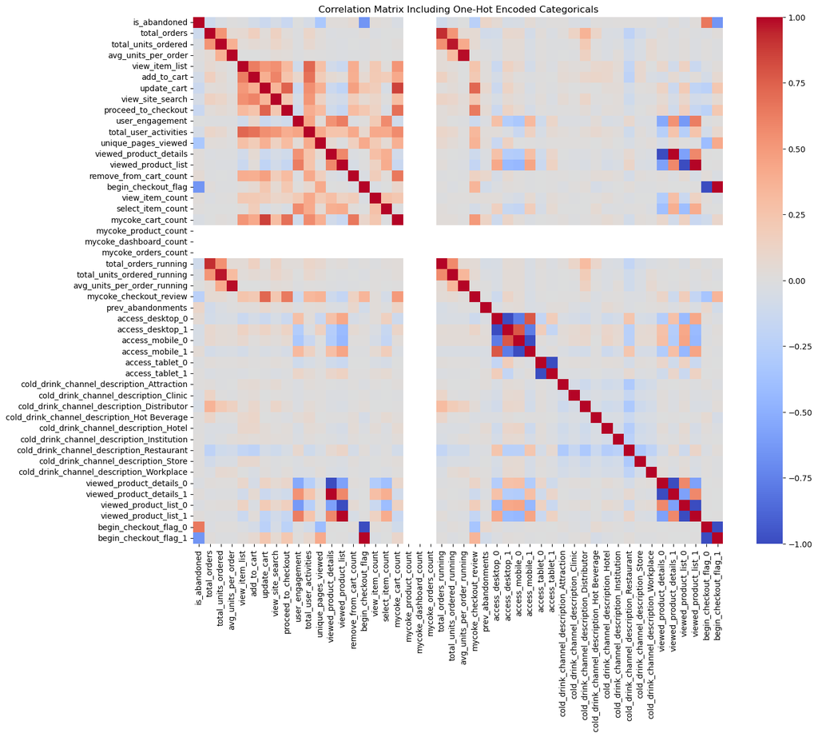

```
Correlation with is_abandoned:
 is_abandoned                                   1.000000
begin_checkout_flag_0                          0.652496
prev_abandonments                              0.103010
remove_from_cart_count                         0.049061
access_desktop_0                               0.048291
access_mobile_1                                0.043426
view_item_count                                0.028956
viewed_product_details                         0.020839
viewed_product_details_1                       0.020839
viewed_product_list                            0.016606
viewed_product_list_1                          0.016606
cold_drink_channel_description_Hot Beverage    0.014622
cold_drink_channel_description_Workplace       0.013909
cold_drink_channel_description_Store           0.012633
cold_drink_channel_description_Restaurant      0.011999
access_tablet_1                                0.011653
cold_drink_channel_description_Attraction      0.011545
select_item_count                              0.009413
cold_drink_channel_description_Institution     0.009405
avg_units_per_order                            0.005858
cold_drink_channel_description_Hotel           0.002229
avg_units_per_order_running                   -0.000336
user_engagement                               -0.003171
access_tablet_0                               -0.011653
view_item_list                                -0.012764
viewed_product_list_0                         -0.016606
viewed_product_details_0                      -0.020839
cold_drink_channel_description_Clinic         -0.027566
total_units_ordered_running                   -0.032020
mycoke_cart_count                             -0.036098
total_units_ordered                           -0.036302
access_mobile_0                               -0.043426
access_desktop_1                              -0.048291
cold_drink_channel_description_Distributor    -0.053407
view_site_search                              -0.058836
total_user_activities                         -0.060141
add_to_cart                                   -0.076042
total_orders_running                          -0.101490
total_orders                                  -0.116839
update_cart                                   -0.131149
proceed_to_checkout                           -0.142430
mycoke_checkout_review                        -0.241929
unique_pages_viewed                           -0.322871
begin_checkout_flag                           -0.652496
begin_checkout_flag_1                         -0.652496
mycoke_product_count                                NaN
mycoke_dashboard_count                              NaN
mycoke_orders_count                                 NaN
Name: is_abandoned, dtype: float64
```

```python
# Select categorical columns (exclude target)
categorical_cols = [
    'access_desktop', 'access_mobile', 'access_tablet', 'cold_drink_channel_description', 'viewed_product_details', 'viewed_product_list', 'begin_checkout_flag'
]

# One-hot encode categorical features
ohe = OneHotEncoder(sparse_output=False, drop=None)
X_cat = ohe.fit_transform(windows_modelling[categorical_cols])

X_cat_df = pd.DataFrame(
    X_cat,
    columns=ohe.get_feature_names_out(categorical_cols),
    index=windows_modelling.index
)

# Select numeric columns (exclude target 'is_abandoned')
numeric_cols = windows_modelling.select_dtypes(include=['int64', 'float64']).columns.tolist()

# Combine one-hot encoded categorical features and numeric features
# Keep 'is_abandoned' as numeric (0/1) for correlation
data_for_corr = pd.concat(
    [windows_modelling['is_abandoned'].astype(int), windows_modelling[numeric_cols], X_cat_df], axis=1
)

# Compute correlation
corr_matrix = data_for_corr.corr()

# Display correlation matrix heatmap
plt.figure(figsize=(15,12))
sns.heatmap(corr_matrix, annot=False, cmap='coolwarm', center=0)
plt.title("Correlation Matrix Including One-Hot Encoded Categoricals")
plt.show()

# Correlation with target only
target_corr = corr_matrix['is_abandoned'].sort_values(ascending=False)
print("Correlation with is_abandoned:\n", target_corr)
```

```python
from sklearn.utils import resample

# Features & target
y = windows_modelling['is_abandoned']
X = windows_modelling.drop(columns=['is_abandoned', 'missed_reorder'])

# Train/test split
X_train, X_test, y_train, y_test = train_test_split(
    X, y, test_size=0.2, random_state=42, stratify=y
)

# Downsample majority class
train_data = pd.concat([X_train, y_train], axis=1)
majority = train_data[train_data['is_abandoned'] == 0]
minority = train_data[train_data['is_abandoned'] == 1]

majority_downsampled = resample(
    majority,
    replace=False,
    n_samples=len(minority),
    random_state=42
)

train_downsampled = pd.concat([minority, majority_downsampled]).sample(frac=1, random_state=42)

X_train_down = train_downsampled.drop(columns=['is_abandoned'], errors='ignore')
y_train_down = train_downsampled['is_abandoned']

# Select categorical columns (exclude target and already dropped columns)
categorical_cols = [
    'access_desktop', 'access_mobile', 'access_tablet', 'cold_drink_channel_description', 'viewed_product_details', 'viewed_product_list', 'begin_checkout_flag'
]

# Initialize OneHotEncoder
ohe = OneHotEncoder(handle_unknown='ignore', sparse_output=False)

# Fit on training data and transform
X_train_cat = ohe.fit_transform(X_train_down[categorical_cols])
X_test_cat = ohe.transform(X_test[categorical_cols])

# Convert to DataFrame with proper column names
X_train_cat = pd.DataFrame(X_train_cat, columns=ohe.get_feature_names_out(categorical_cols), index=X_train_down.index)
X_test_cat = pd.DataFrame(X_test_cat, columns=ohe.get_feature_names_out(categorical_cols), index=X_test.index)

# Drop original categorical columns and concatenate encoded ones
X_train_down = pd.concat([X_train_down.drop(columns=categorical_cols), X_train_cat], axis=1)
X_test = pd.concat([X_test.drop(columns=categorical_cols), X_test_cat], axis=1)


# Identify numeric columns (exclude already one-hot encoded categorical columns)
numeric_cols = X_train_down.select_dtypes(include=['int64', 'float64']).columns

scaler = StandardScaler()
X_train_down[numeric_cols] = scaler.fit_transform(X_train_down[numeric_cols])
X_test[numeric_cols] = scaler.transform(X_test[numeric_cols])
```

```python
X_train_down.info()
```

```
<class 'pandas.core.frame.DataFrame'>
Index: 4948 entries, 1130 to 33957
Data columns (total 44 columns):
 #   Column                                       Non-Null Count  Dtype
---  ------                                       --------------  -----
 0   total_orders                                 4948 non-null   float64
 1   total_units_ordered                          4948 non-null   float64
 2   avg_units_per_order                          4948 non-null   float64
 3   view_item_list                               4948 non-null   float64
 4   add_to_cart                                  4948 non-null   float64
 5   update_cart                                  4948 non-null   float64
 6   view_site_search                             4948 non-null   float64
 7   proceed_to_checkout                          4948 non-null   float64
 8   user_engagement                              4948 non-null   float64
 9   total_user_activities                        4948 non-null   float64
```

[output cut: 36 more lines]

### Logistic Regression

```python
## Step 4: Modelling
logistic_regression = LogisticRegression(class_weight='balanced', max_iter=1000)
logistic_regression.fit(X_train_down, y_train_down)
y_pred_lr = logistic_regression.predict(X_test)
print("=== Logistic Regression ===")
print(classification_report(y_test, y_pred_lr))
```

```
=== Logistic Regression ===
              precision    recall  f1-score   support

           0       0.98      0.94      0.96      5482
           1       0.59      0.79      0.68       618

    accuracy                           0.92      6100
   macro avg       0.78      0.87      0.82      6100
weighted avg       0.94      0.92      0.93      6100
```

```python
from sklearn.metrics import make_scorer, f1_score, precision_score, recall_score

cv = StratifiedKFold(n_splits=5, shuffle=True, random_state=42)

f1_scorer = make_scorer(f1_score)
precision_scorer = make_scorer(precision_score)
recall_scorer = make_scorer(recall_score)

# F1-score CV
f1_scores = cross_val_score(logistic_regression, X_train_down, y_train_down, cv=cv, scoring=f1_scorer)
precision_scores = cross_val_score(logistic_regression, X_train_down, y_train_down, cv=cv, scoring=precision_scorer)
recall_scores = cross_val_score(logistic_regression, X_train_down, y_train_down, cv=cv, scoring=recall_scorer)

print(f"F1-score (CV): {f1_scores.mean():.4f} ± {f1_scores.std():.4f}")
print(f"Precision (CV): {precision_scores.mean():.4f} ± {precision_scores.std():.4f}")
print(f"Recall (CV): {recall_scores.mean():.4f} ± {recall_scores.std():.4f}")

# Train on full training set
logistic_regression.fit(X_train_down, y_train_down)
y_pred_lr = logistic_regression.predict(X_test)

# Evaluate
from sklearn.metrics import classification_report
print("=== Logistic Regression on Test Set ===")
print(classification_report(y_test, y_pred_lr))
```

```
F1-score (CV): 0.8628 ± 0.0104
Precision (CV): 0.9261 ± 0.0110
Recall (CV): 0.8080 ± 0.0208
=== Logistic Regression on Test Set ===
              precision    recall  f1-score   support

           0       0.98      0.94      0.96      5482
           1       0.59      0.79      0.68       618

    accuracy                           0.92      6100
   macro avg       0.78      0.87      0.82      6100
weighted avg       0.94      0.92      0.93      6100
```

```python
# If using one-hot encoded X_train_down
feature_names = X_train_down.columns
coefficients = logistic_regression.coef_[0]

# Create a DataFrame
coef_df = pd.DataFrame({'feature': feature_names, 'coefficient': coefficients})

# Absolute value shows impact magnitude
coef_df['abs_coeff'] = coef_df['coefficient'].abs()

# Sort by absolute impact
coef_df_sorted = coef_df.sort_values(by='abs_coeff', ascending=False)
print(coef_df_sorted)
```

```
                                        feature  coefficient  abs_coeff
0                                  total_orders    -1.539198   1.539198
42                        begin_checkout_flag_0     0.916050   0.916050
43                        begin_checkout_flag_1    -0.916050   0.916050
10                          unique_pages_viewed    -0.908555   0.908555
2                           avg_units_per_order     0.494842   0.494842
20                  avg_units_per_order_running    -0.422600   0.422600
4                                   add_to_cart    -0.410869   0.410869
9                         total_user_activities     0.371496   0.371496
18                         total_orders_running     0.272931   0.272931
11                       remove_from_cart_count     0.189148   0.189148
25                              access_mobile_0    -0.160796   0.160796
26                              access_mobile_1     0.160796   0.160796
6                              view_site_search    -0.159140   0.159140
14                            mycoke_cart_count     0.157591   0.157591
```

[output cut: 30 more lines]

```python
from sklearn.ensemble import GradientBoostingClassifier

# Boosted Logistic Regression (Gradient Boosting with logistic loss)
blr = GradientBoostingClassifier(
    n_estimators=200,
    learning_rate=0.1,
    max_depth=3,
    random_state=42
)
blr.fit(X_train_down, y_train_down)
y_pred_blr = blr.predict(X_test)
print("=== Boosted Logistic Regression ===")
print(classification_report(y_test, y_pred_blr))
```

```
=== Boosted Logistic Regression ===
              precision    recall  f1-score   support

           0       0.98      0.93      0.96      5482
           1       0.58      0.87      0.70       618

    accuracy                           0.92      6100
   macro avg       0.78      0.90      0.83      6100
weighted avg       0.94      0.92      0.93      6100
```

### Decision Tree

```python
# Decision Tree
from sklearn.metrics import accuracy_score

dt = DecisionTreeClassifier(max_depth=6, min_samples_leaf=20, random_state=42)
dt.fit(X_train_down, y_train_down)
y_pred_dt = dt.predict(X_test)
print("=== Decision Tree ===")
print(classification_report(y_test, y_pred_dt))

accuracy = accuracy_score(y_test, y_pred_dt)
print(f"Decision Tree Accuracy: {accuracy:.4f}")
```

```
=== Decision Tree ===
              precision    recall  f1-score   support

           0       0.98      0.94      0.96      5482
           1       0.61      0.86      0.71       618

    accuracy                           0.93      6100
   macro avg       0.80      0.90      0.84      6100
weighted avg       0.95      0.93      0.93      6100

Decision Tree Accuracy: 0.9298
```

### Gradient Boosting

```python
# Gradient Boosting with regularization
gb = HistGradientBoostingClassifier(max_iter=300, learning_rate=0.05, max_depth=5, random_state=42)
gb.fit(X_train_down, y_train_down)
y_pred_gb = gb.predict(X_test)
print("=== Gradient Boosting ===")
print(classification_report(y_test, y_pred_gb))


# Compute accuracy
accuracy = accuracy_score(y_test, y_pred_gb)
print(f"Gradient Boosting Accuracy: {accuracy:.4f}")
```

```
=== Gradient Boosting ===
              precision    recall  f1-score   support

           0       0.98      0.93      0.96      5482
           1       0.58      0.87      0.69       618

    accuracy                           0.92      6100
   macro avg       0.78      0.90      0.82      6100
weighted avg       0.94      0.92      0.93      6100

Gradient Boosting Accuracy: 0.9221
```

```
=== XGBoost Classification Report ===
              precision    recall  f1-score   support

           0       0.98      0.93      0.96      5482
           1       0.59      0.87      0.70       618

    accuracy                           0.93      6100
   macro avg       0.79      0.90      0.83      6100
weighted avg       0.94      0.93      0.93      6100
```

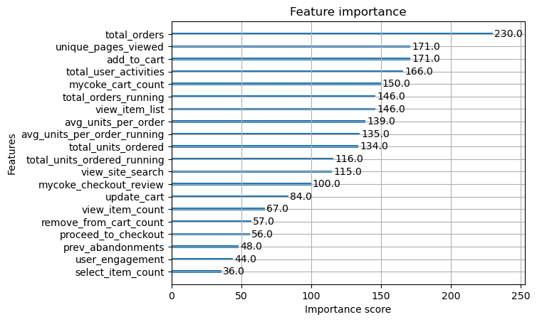

```python
import xgboost as xgb

# compute scale_pos_weight for imbalance
scale_pos_weight = y_train_down.value_counts()[0] / y_train_down.value_counts()[1]

# Train XGBoost classifier
xgb_model = xgb.XGBClassifier(
    objective='binary:logistic',
    scale_pos_weight=scale_pos_weight,
    eval_metric='logloss',
    use_label_encoder=False,
    random_state=42,
    n_estimators=200,
    max_depth=4,
    learning_rate=0.1
)

xgb_model.fit(X_train_down, y_train_down)

# Predict
y_pred = xgb_model.predict(X_test)

# Evaluate
print("=== XGBoost Classification Report ===")
print(classification_report(y_test, y_pred))

# Feature importance
xgb.plot_importance(xgb_model, max_num_features=20, importance_type='weight')
plt.show()
```

```
=== LightGBM Classification Report ===
              precision    recall  f1-score   support

           0       0.98      0.93      0.96      5482
           1       0.58      0.87      0.70       618

    accuracy                           0.92      6100
   macro avg       0.78      0.90      0.83      6100
weighted avg       0.94      0.92      0.93      6100
```

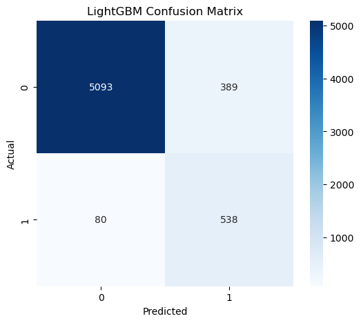

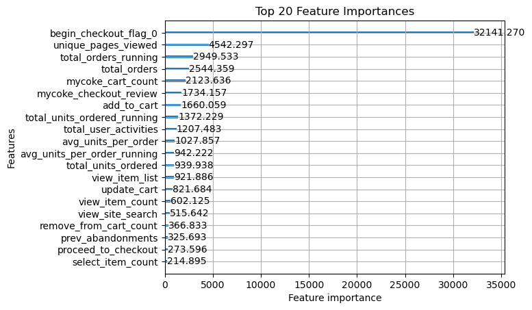

```python
import lightgbm as lgb

# Optional: compute class weight to handle imbalance
scale_pos_weight = y_train_down.value_counts()[0] / y_train_down.value_counts()[1]

lgb_model = lgb.LGBMClassifier(
    objective='binary',
    n_estimators=300,
    learning_rate=0.05,
    max_depth=5,
    scale_pos_weight=scale_pos_weight,
    random_state=42,
    verbose=-1  # suppress messages
)

lgb_model.fit(X_train_down, y_train_down)

y_pred = lgb_model.predict(X_test)

print("=== LightGBM Classification Report ===")
print(classification_report(y_test, y_pred))

# Optional: confusion matrix
cm = confusion_matrix(y_test, y_pred)
plt.figure(figsize=(6,5))
sns.heatmap(cm, annot=True, fmt='d', cmap='Blues')
plt.xlabel('Predicted')
plt.ylabel('Actual')
plt.title('LightGBM Confusion Matrix')
plt.show()

lgb.plot_importance(lgb_model, max_num_features=20, importance_type='gain')
plt.title('Top 20 Feature Importances')
plt.show()
```